# Results

R. Vezy

01/09/2020

## Project set up

Set up libraries:

Load data:

## Data analysis

### Density

We used three different methodologies for measuring the sample volume:

- measuring the fresh sample as it is;
- put the sample into water for hydration for ~2 days with bark;
- put the sample into water for hydration for ~2 days and removing the bark

Comparing the resulting volumes tells us that measuring the volume on the fresh sample gives values close to hydrated samples with bark (see fig. below)

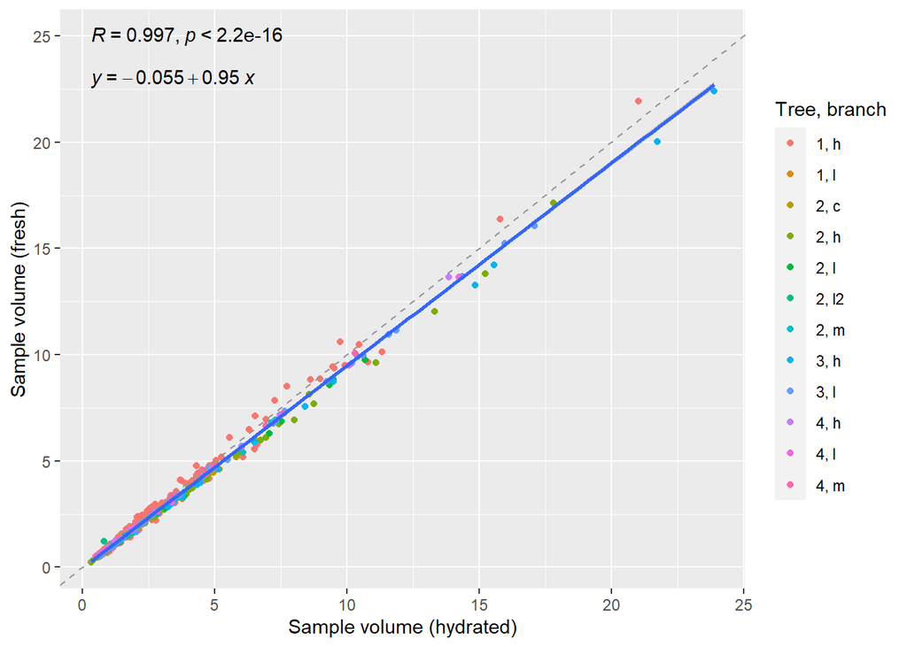

This method allows for a faster estimation of the sample volume, with a low bias (0.223993).

Our approach includes the bark because our objective is to evaluate the total biomass that can be exploited by pruning of branches, then including bark (it can be of interest for e.g. chemistry). Removing the bark from the sample gives different estimations of the volume though, especially for bigger samples:

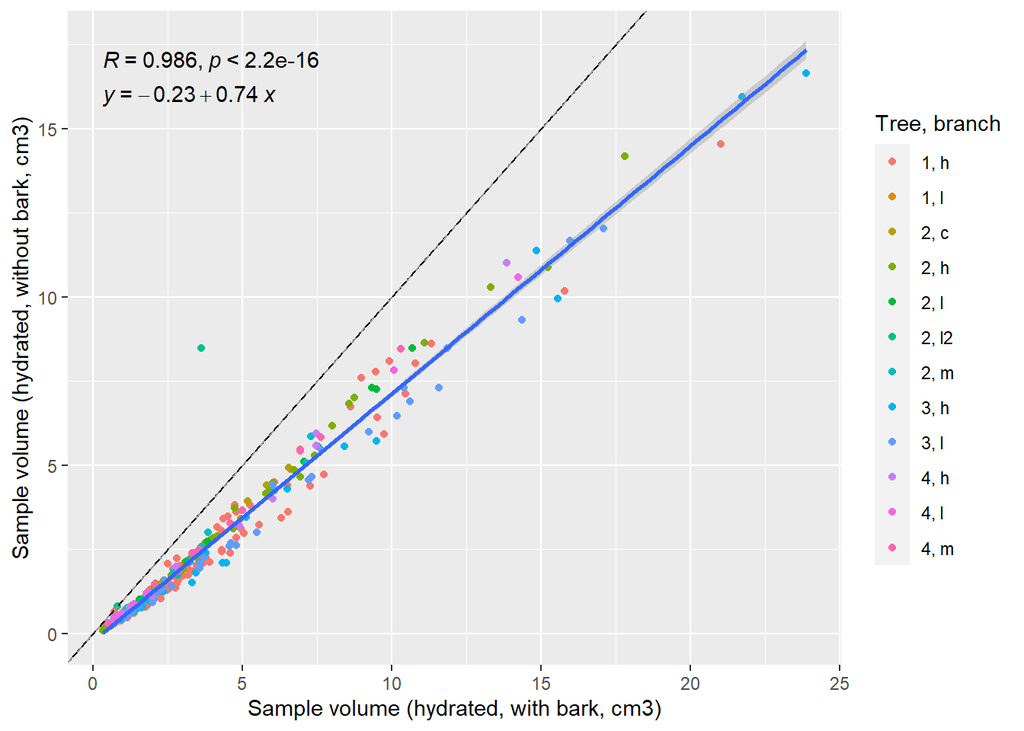

But the difference stabilizes when we look at relative values:

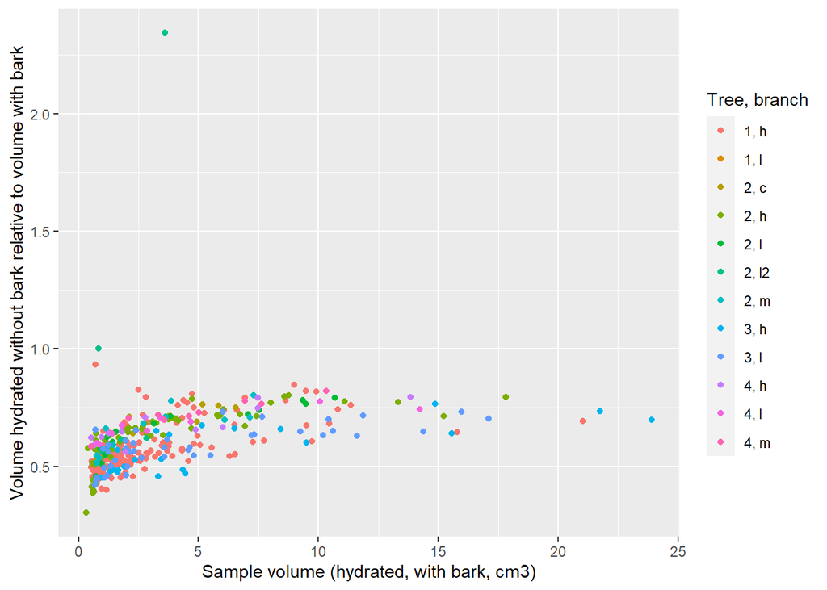

The wood density is highly variable between trees, branches and also segments. No clear trend was found with any of the available variables:

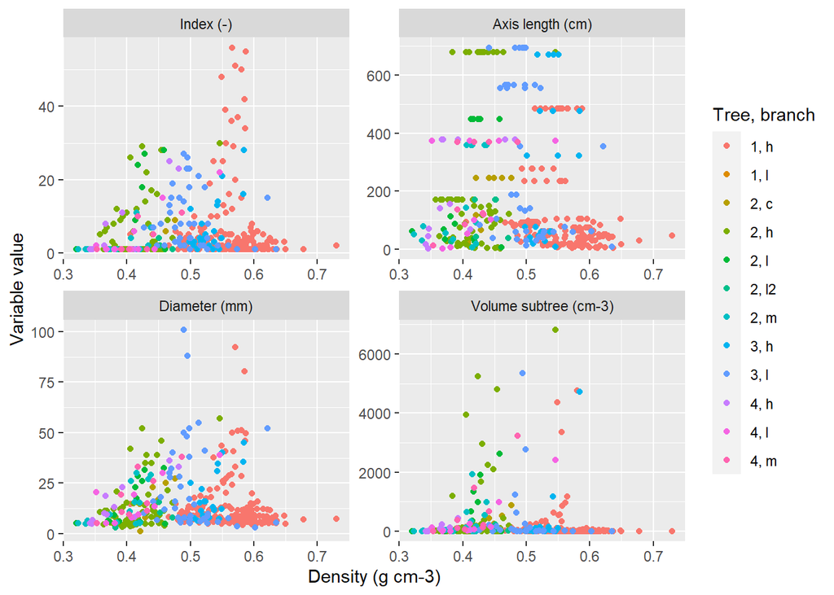

The variability in the density appears to be linked to other variables that were not measured in this study (e.g. biomecanics, age…).

The average density across all branches is 0.4975663.

### Dimensions

We can test the pipe model by comparing the cross section of each segment to the sum of the cross-section of the segments it bears. If the pipe model is respected, both variables should be close.

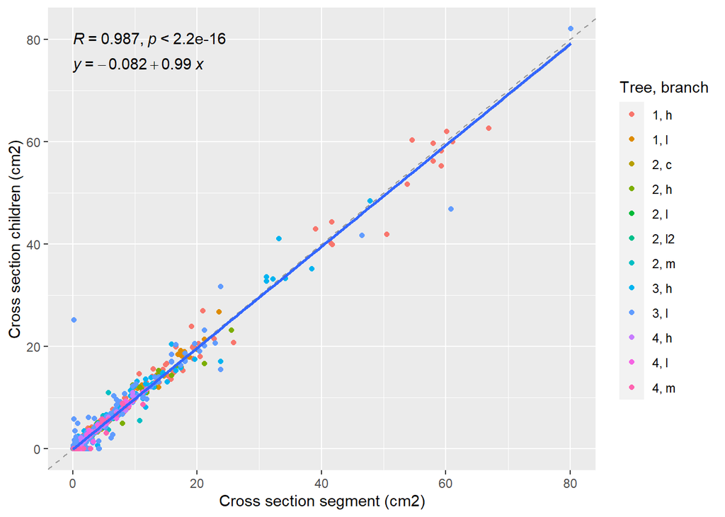

The plot above shows that both variables have close values, which indicates that the pipe model is respected.

In theory, this comparison can be made using any topological order, the extreme being comparing the cross section of a segment with the sum of the cross sections of the terminal segments borne by the reference segment.

Here is a plot of this comparison:

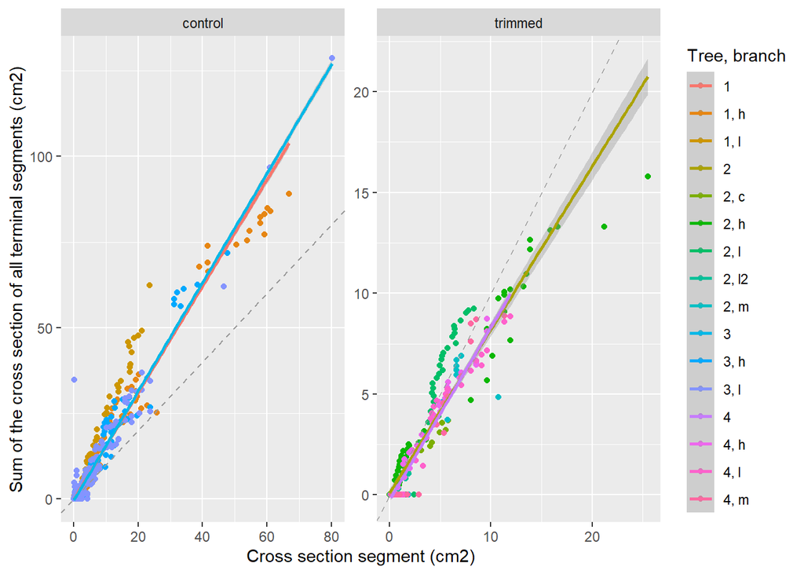

Here we can see that this relationship holds quite well for the branches from the trees that are regularly trimmed. However, the relationship is not following the identity line in the control treatment where the branches grew freely, but the slope of the relationship is still linear, with smallest segments (i.e. the ones with the lowest cross section) having the closest cross-section compared to the sum of the cross sections of the terminal segments. This can be explained by a cumulative effect (the lower the cross section of the segment of reference, the closest to the extremity).

This hypothesis is verified by the plot below that shows there is a tendency between this difference in cross sections and the total length of the segments supported by the segment.

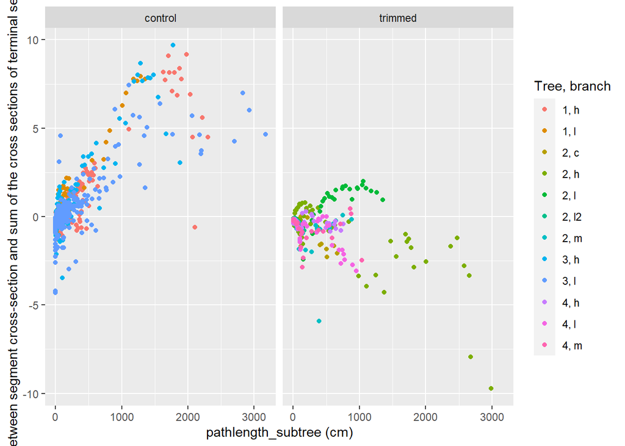

Four candidate variables where chosen as potential predictors to predict the segment cross section (and then diameter). Here is a plot presenting the relationships between those variables and the cross section:

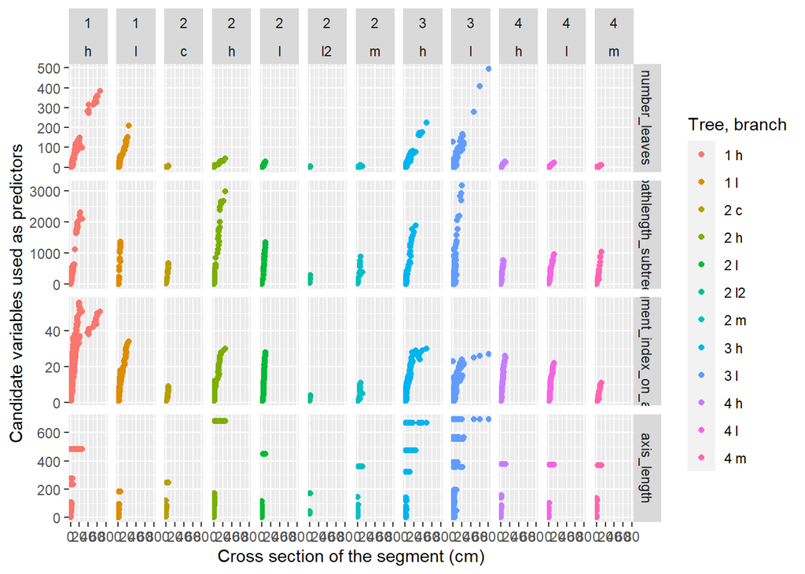

The number of terminal segments is a good proxy of the sum of their cross section (see plot below). This is particularly of interest considering that the cross section is the target variable to predict, while the number of terminal segments can be retrieved from LiDAR measurement.

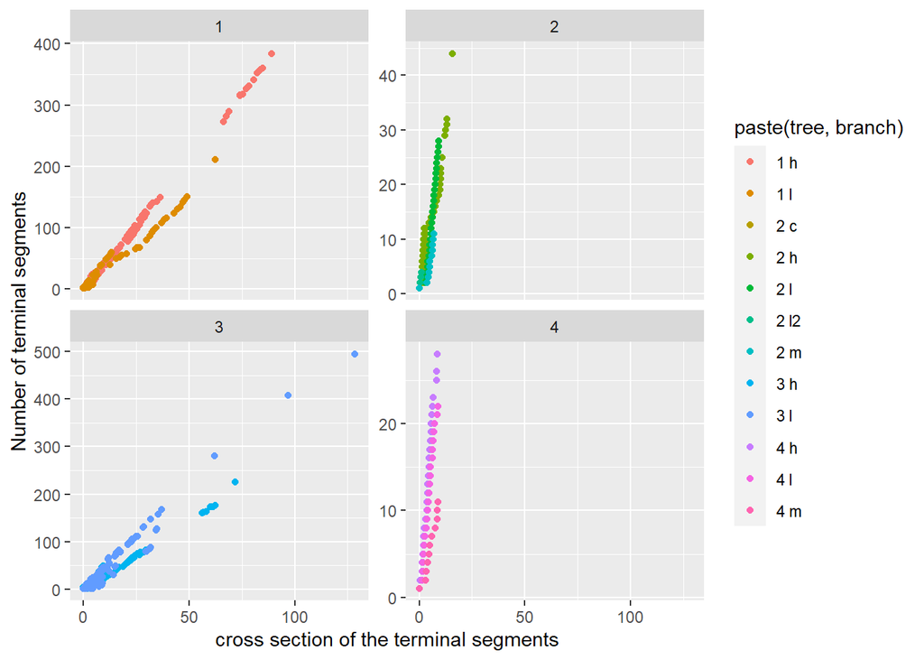

## Modelling

Choosing the equation:

```r
formula = cross_section ~ pathlength_subtree + segment_index_on_axis
min_diam = 20
```

Fitting the general model:

```r
model = fit_model(data = df_mtg, formula = formula, min_diam = min_diam)
```

Here is the model summary:

```r
summary(model$model)
```

```
##
## Call:
## lm(formula = formula, data = data)
##
## Residuals:
##     Min      1Q  Median      3Q     Max
## -7.1736 -0.1564 -0.0625  0.0424  9.4865
##
## Coefficients:
##                        Estimate Std. Error t value Pr(>|t|)
## (Intercept)           5.024e-02  1.818e-02   2.763  0.00577 **
## pathlength_subtree    5.463e-03  9.132e-05  59.822  < 2e-16 ***
## segment_index_on_axis 1.363e-01  5.280e-03  25.822  < 2e-16 ***
## ---
## Signif. codes:  0 '***' 0.001 '**' 0.01 '*' 0.05 '.' 0.1 ' ' 1
##
## Residual standard error: 0.7884 on 2634 degrees of freedom
##   (291 observations deleted due to missingness)
## Multiple R-squared:  0.9035, Adjusted R-squared:  0.9035
## F-statistic: 1.234e+04 on 2 and 2634 DF,  p-value: < 2.2e-16
```

Using a branch-scale correction:

```r
res = apply_model_cor(data = df_mtg, model = model$model, min_diam = 20)
```

Using a cross-validation (leave-one-out) scheme to evaluate our model:

```r
df_cross = cross_validate(data = df_mtg, formula = formula, min_diam = min_diam)
```

The statistics:

- on the whole branch:

| type | nrmse | EF | Bias |
| --- | --- | --- | --- |
| general | 55.85558 | 0.7760235 | 0.2810186 |
| corrected | 39.27373 | 0.9107015 | 0.0514192 |

- on the segments with diameter lower or equal to 20:

| type | nrmse | EF | Bias |
| --- | --- | --- | --- |
| general | 63.78095 | 0.5855040 | 0.0045619 |
| corrected | 62.62567 | 0.6399268 | -0.0574371 |

The final prediction colored by branch compared to the measurements:

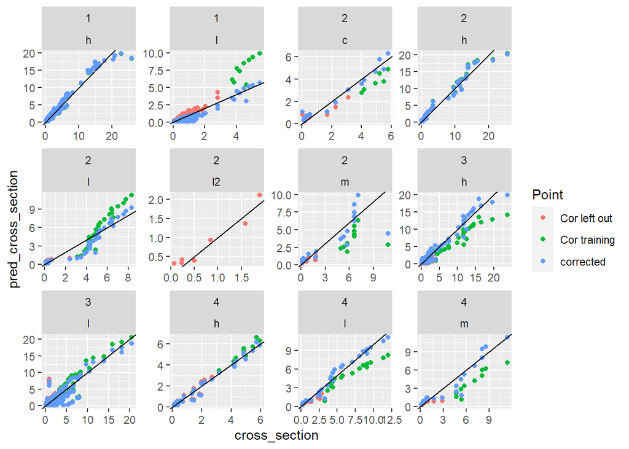

All in one plot:

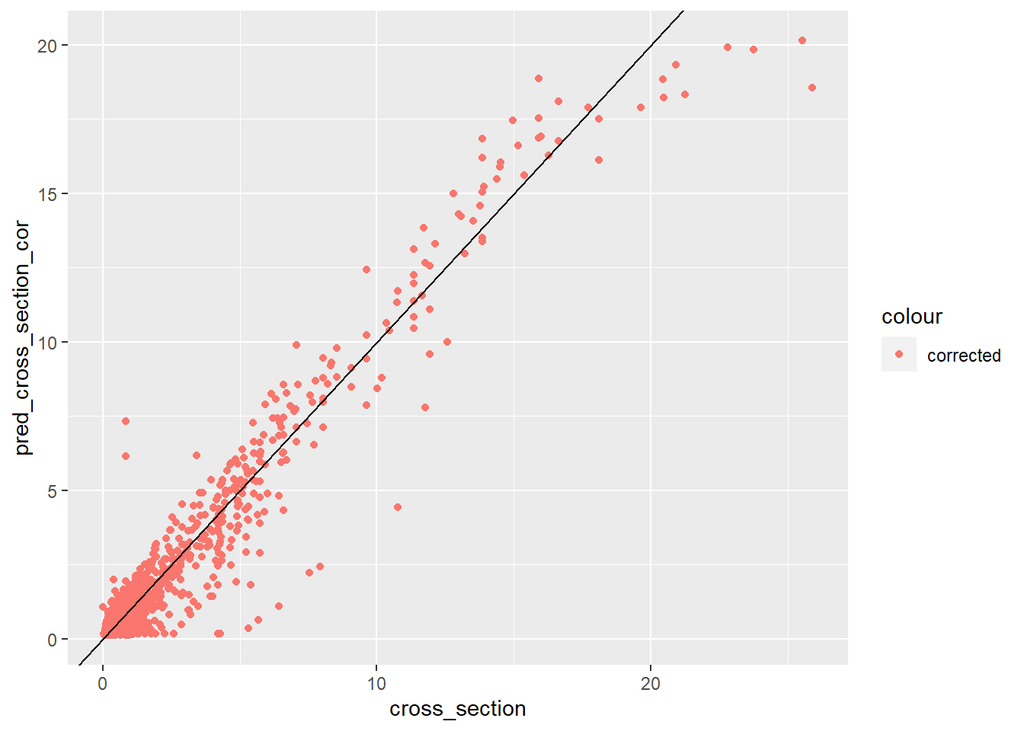

### Biomass prediction

It is now straightforward to predict the wood dry biomass at different scales using our model. The model is used to predict the cross section of the segments with a diameter lower or equal to 20, as the LiDAR measures well the ones with higher dimensions.

- At the scale of the segment:

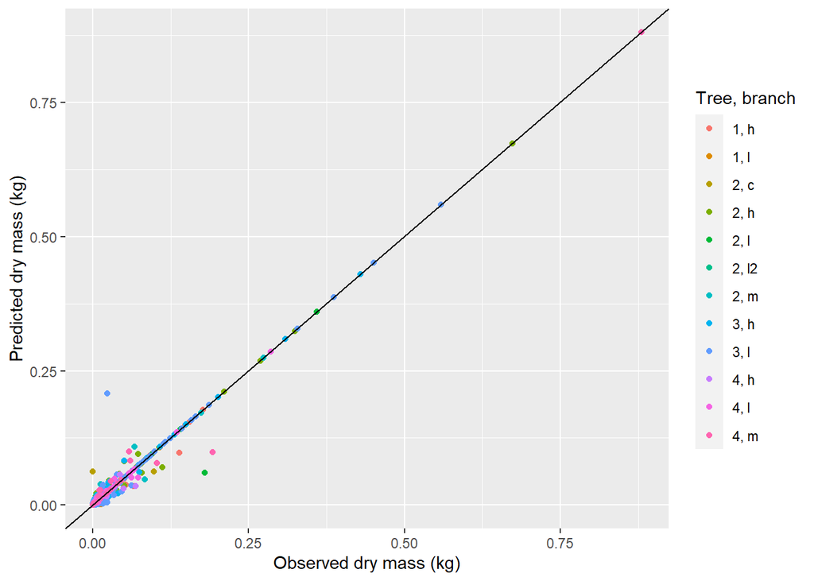

- At the scale of the whole branch:

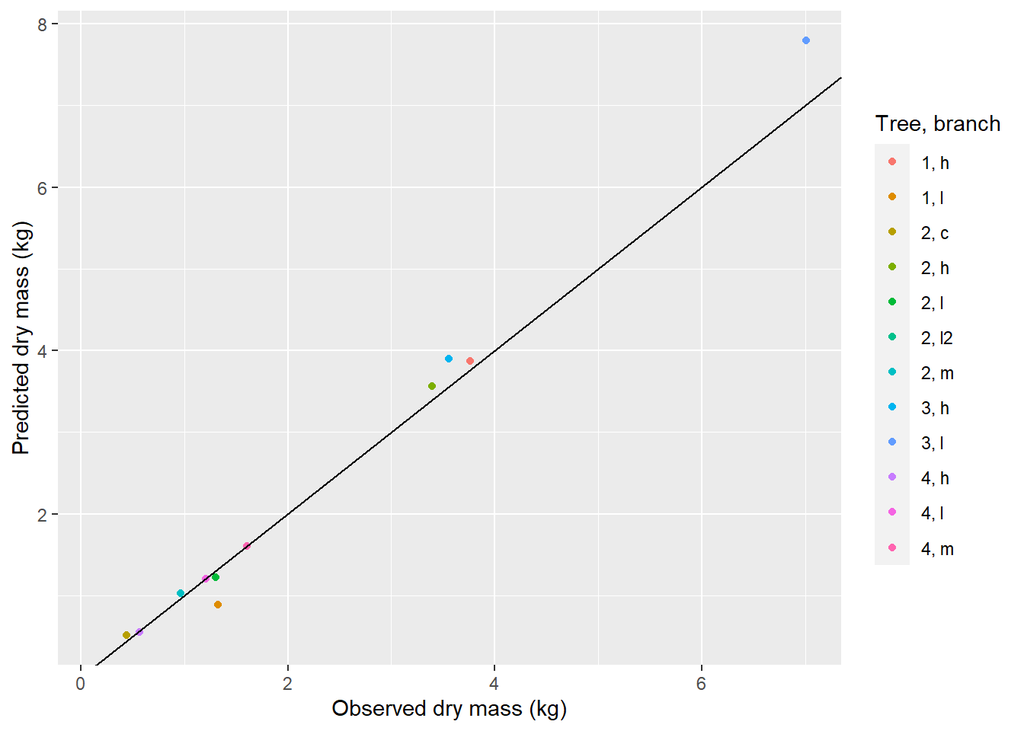

- And using the segments with a diameter lower or equal than 20:

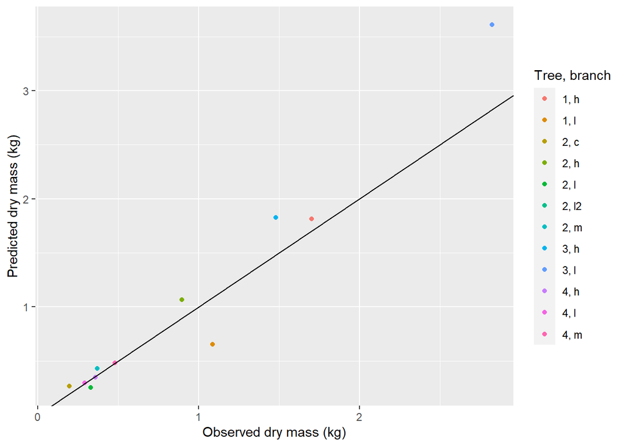

The biomass of the segments with a diameter lower or equal than 20 relative to the total biomass of the branch:

| mean | sd |
| --- | --- |
| 0.468328 | 0.2368268 |